# hw8

# Whisky Data read

```r
df = read.csv('whisky.csv')

colnames(df)
```

```
##  [1] "RowID"      "Distillery" "Body"       "Sweetness"  "Smoky"
##  [6] "Medicinal"  "Tobacco"    "Honey"      "Spicy"      "Winey"
## [11] "Nutty"      "Malty"      "Fruity"     "Floral"     "Postcode"
## [16] "Latitude"   "Longitude"
```

```r
head(df)
```

```
##   RowID  Distillery Body Sweetness Smoky Medicinal Tobacco Honey Spicy Winey
## 1     1   Aberfeldy    2         2     2         0       0     2     1     2
## 2     2    Aberlour    3         3     1         0       0     4     3     2
## 3     3      AnCnoc    1         3     2         0       0     2     0     0
## 4     4      Ardbeg    4         1     4         4       0     0     2     0
## 5     5     Ardmore    2         2     2         0       0     1     1     1
## 6     6 ArranIsleOf    2         3     1         1       0     1     1     1
##   Nutty Malty Fruity Floral   Postcode Latitude Longitude
## 1     2     2      2      2 \tPH15 2EB   286580    749680
## 2     2     3      3      2 \tAB38 9PJ   326340    842570
## 3     2     2      3      2  \tAB5 5LI   352960    839320
## 4     1     2      1      0 \tPA42 7EB   141560    646220
## 5     2     3      1      1 \tAB54 4NH   355350    829140
## 6     0     1      1      2   KA27 8HJ   194050    649950
```

Import all libraries

```r
library(leaflet)
library(dplyr)
library(Hmisc)
library(rgdal)
library(sf)
```

```r
library(maps)
library(ggplot2)
library(tidyverse)
library(mlbench)
library(caret)
library('corrplot')
```

Get additional info per column/feature

```r
describe(df)
```

```
## df
##
##  17  Variables      86  Observations
## --------------------------------------------------------------------------------
## RowID
##        n  missing distinct     Info     Mean      Gmd      .05      .10
##       86        0       86        1     43.5       29     5.25     9.50
##      .25      .50      .75      .90      .95
##    22.25    43.50    64.75    77.50    81.75
##
## lowest :  1  2  3  4  5, highest: 82 83 84 85 86
## --------------------------------------------------------------------------------
## Distillery
##        n  missing distinct
##       86        0       86
##
## lowest : Aberfeldy    Aberlour     AnCnoc       Ardbeg       Ardmore
## highest: Tobermory    Tomatin      Tomintoul    Tormore      Tullibardine
## --------------------------------------------------------------------------------
## Body
##        n  missing distinct     Info     Mean      Gmd
##       86        0        5    0.843     2.07   0.9702
##
## lowest : 0 1 2 3 4, highest: 0 1 2 3 4
##
## Value          0     1     2     3     4
## Frequency      2    19    45    11     9
## Proportion 0.023 0.221 0.523 0.128 0.105
## --------------------------------------------------------------------------------
## Sweetness
##        n  missing distinct     Info     Mean      Gmd
##       86        0        4    0.826    2.291   0.7488
##
## Value          1     2     3     4
## Frequency     10    44    29     3
## Proportion 0.116 0.512 0.337 0.035
## --------------------------------------------------------------------------------
## Smoky
##        n  missing distinct     Info     Mean      Gmd
##       86        0        5    0.822    1.535   0.8651
```

[output cut: 95 more lines]

```
##       86        0       77        1   287247    70797   140712   151555
##      .25      .50      .75      .90      .95
##   265672   319515   328630   342750   354752
##
## lowest : 126680 131330 137950 138680 140430, highest: 355350 361200 370860 372120 381020
## --------------------------------------------------------------------------------
## Longitude
##        n  missing distinct     Info     Mean      Gmd      .05      .10
##       86        0       77        1   802660    92294   645852   664045
##      .25      .50      .75      .90      .95
##   755698   839885   850770   863145   885190
##
## lowest :  554260  620910  621010  645160  645730
## highest:  885770  904230  950130 1008930 1009260
## --------------------------------------------------------------------------------
```

With descibe() we can see the range of values that each column has as we can see they get values from 0 - 4 except columns with Distillery, postcode and Lat/Long. We also can observe the frequency of appearence of every value for a column

# Validate use of cordiantes

```r
validateCoords(df$Longitude,df$Latitude,funcName = addCircleMarkers(),warn=TRUE)
```

[output not shown]

[output cut: 72 more lines]

#About Longtitude latitude data

They are in United Kingdom Coordinate System (EPSG 27700). Therefore, we need to transform them into World Coordinate System (WGS84 (EPSG4326)). So we have to convert the data first before print the map.

```r
df$Longitude = as.numeric(df$Longitude)
df$Latitude = as.numeric(df$Latitude)
head(df)
```

```
##   RowID  Distillery Body Sweetness Smoky Medicinal Tobacco Honey Spicy Winey
## 1     1   Aberfeldy    2         2     2         0       0     2     1     2
## 2     2    Aberlour    3         3     1         0       0     4     3     2
## 3     3      AnCnoc    1         3     2         0       0     2     0     0
## 4     4      Ardbeg    4         1     4         4       0     0     2     0
## 5     5     Ardmore    2         2     2         0       0     1     1     1
## 6     6 ArranIsleOf    2         3     1         1       0     1     1     1
##   Nutty Malty Fruity Floral   Postcode Latitude Longitude
## 1     2     2      2      2 \tPH15 2EB   286580    749680
## 2     2     3      3      2 \tAB38 9PJ   326340    842570
## 3     2     2      3      2  \tAB5 5LI   352960    839320
## 4     1     2      1      0 \tPA42 7EB   141560    646220
## 5     2     3      1      1 \tAB54 4NH   355350    829140
## 6     0     1      1      2   KA27 8HJ   194050    649950
```

```r
worldMap = map_data('world')
whiskies.coord <- data.frame(df$Latitude, df$Longitude) # dataFrame with long lat columns

coordinates(whiskies.coord) <- ~df.Latitude + df.Longitude # dataFrame converted to Spatial data
proj4string(whiskies.coord) <- CRS("+init=epsg:27700")

whiskies.coord <- spTransform(whiskies.coord, CRS("+init=epsg:4326"))

whisky.map <-

  data.frame(Distillery = df$Distillery,

             lat = whiskies.coord$df.Latitude,

             long = whiskies.coord$df.Longitude)

new.data = merge(df,whisky.map,by='Distillery') # merge old data with new converted lat/long columns

whisky.map = whisky.map %>% rename(long=lat,lat=long) # swap variables to correct order
```

Create a Global Map show case with the distilleries (all based in Scotland)

```r
pal <- colorNumeric(
  palette = "YlGnBu",
  domain = df$Tobacco
)
leaflet()%>%
  addTiles()%>%
    addCircleMarkers(data=whisky.map,  color = ~pal(df$Tobacco),
                       fillOpacity = 1,
                       stroke = F,label = whisky.map$Distillery,clusterOptions = markerClusterOptions())%>%
  addLegend("bottomright",pal = pal,values = df$Tobacco,title = "Tobacco Flavor Whiskies",opacity = 1)
```

```
## Assuming "long" and "lat" are longitude and latitude, respectively
```

[interactive chart not shown]

In the above map we can see the clustered Ditilleries with wiskies that have a specific amount of ‘Tobacco’ flavour. We can use other types of flavors too.

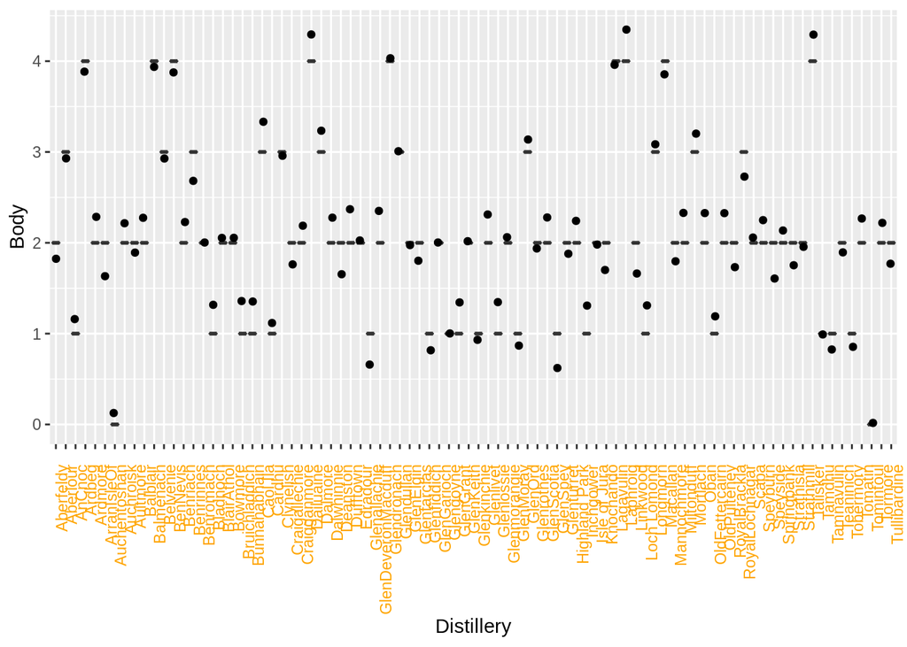

```r
plot1 <- ggplot(df, aes(y=Body,x=Distillery)) +
  geom_boxplot(outlier.colour="red", outlier.shape=16,
             outlier.size=2, notch=FALSE)+
  geom_jitter(width=0.15)+
  theme(axis.text.x = element_text(angle = 90,hjust =1,vjust=1,color = 'orange',margin = margin(t = .3, r =1, unit = "cm")))

plot1
```

Whiskies ‘Body’ strength per Distillery is shown on the above plot.

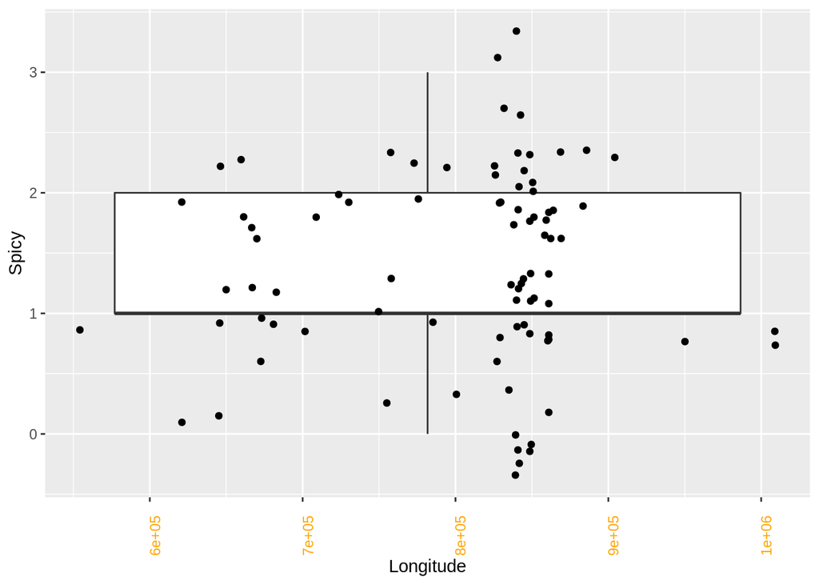

```r
plot2 <- ggplot(new.data, aes(y=Spicy,x=Longitude,group=1)) +
  geom_boxplot(outlier.colour="red", outlier.shape=16,
               outlier.size=2, notch=FALSE)+
  geom_jitter(width=0.15)+
  theme(axis.text.x = element_text(angle = 90,hjust =1,vjust=1,color = 'orange',margin = margin(t = .3, r =1, unit = "cm")))
plot2
```

Where ‘Spicier’ (stronger ‘Spicy’ flavour of wisky) based on Longitude are sailed in Distilleries around this area. We see that Distilleries based in a geographic Longitude between 8*(10^5) <-> 9*(10^5) in United Kingdom Coordinate System (EPSG 27700).

Categorical Variables mosaic plot

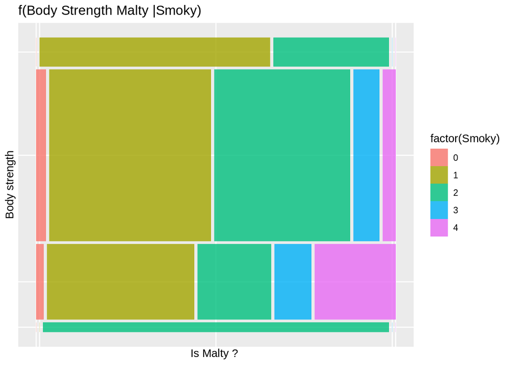

```r
library(ggmosaic)
ggplot(data = df) +
     geom_mosaic(aes(weight = Body, x = product(Malty), fill=factor(Smoky)), na.rm=TRUE, divider=mosaic("v")) +  labs(x = "Is Malty ? ",y='Body strength', title='f(Body Strength Malty |Smoky)')
```

Wiskies Body strength by Malty strength and Smoky flavours.

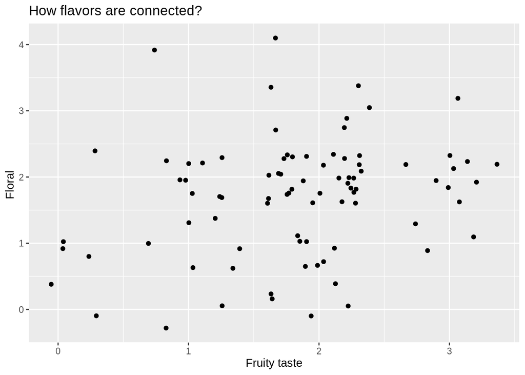

```r
scatter2 <- ggplot(df,aes(x=Fruity,y=Floral))+geom_jitter()

scatter2 +
  labs(x = "Fruity taste", y = "Floral ") +
  ggtitle("How flavors are connected?")
```

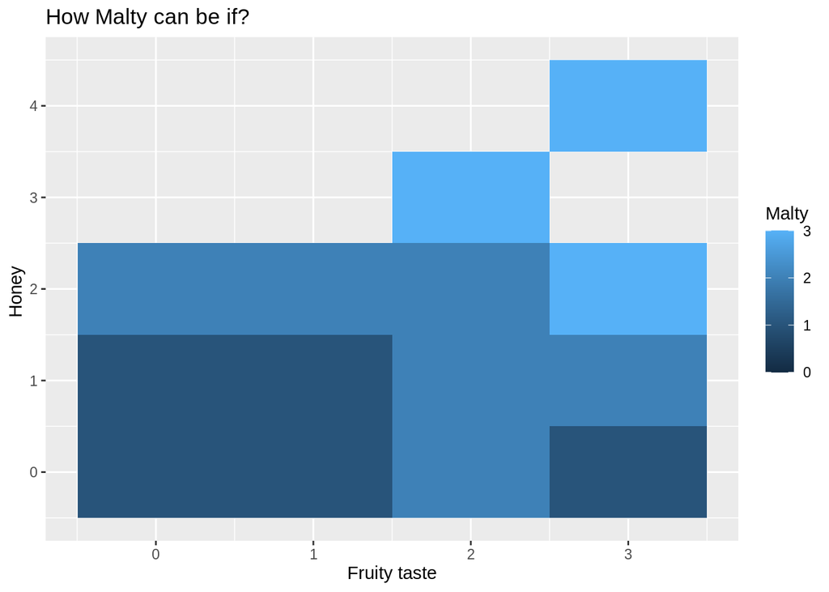

```r
ggplot(df, aes(x = Fruity, y = Honey)) +
    geom_raster(aes(fill = Malty))+
  labs(x = "Fruity taste", y = "Honey ") +
  ggtitle("How Malty can be if?")
```

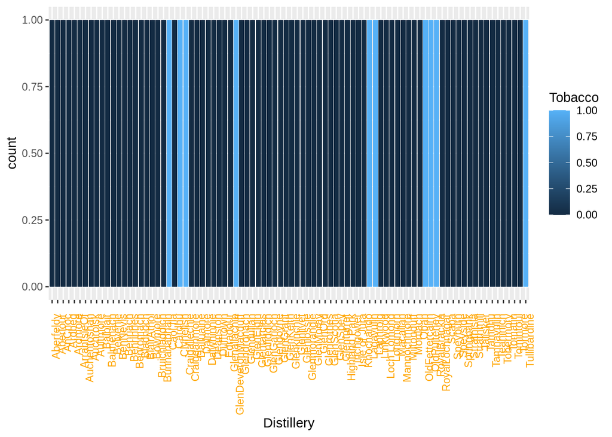

```r
ggplot(df,
       aes(x = Distillery,
           fill = Tobacco)) +
  geom_bar(position = "stack")+
  theme(axis.text.x = element_text(angle = 90,hjust =1,vjust=1,color = 'orange',margin = margin(t = .3, r =1, unit = "cm")))
```

smoky and Medicinal

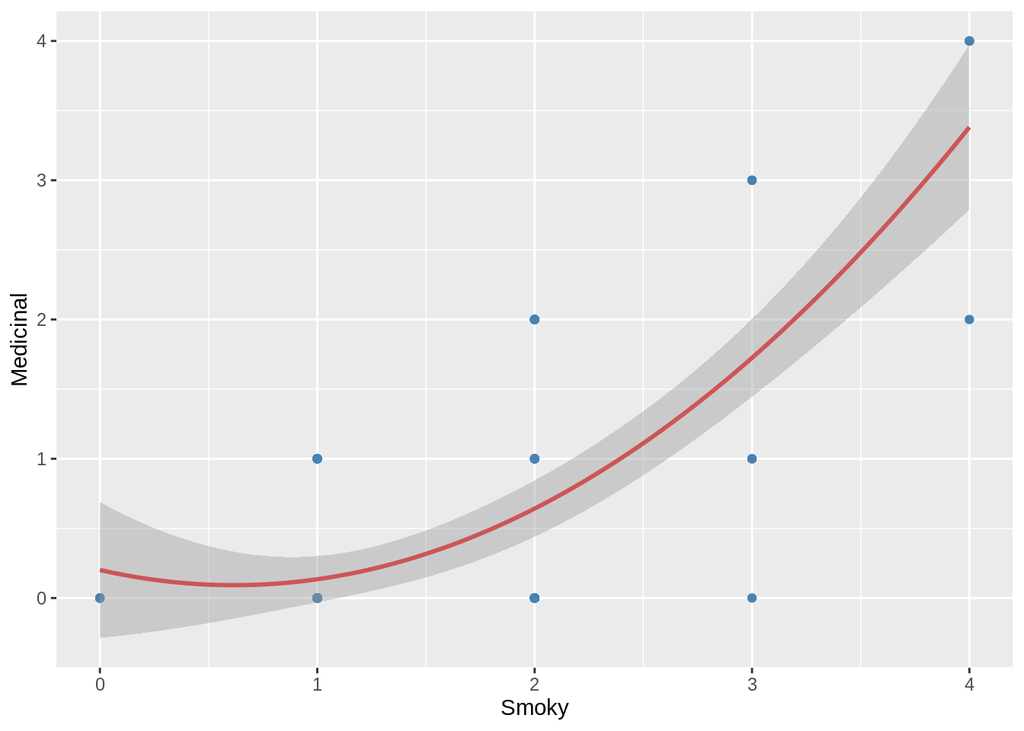

```r
ggplot(df,
       aes(x = Smoky,
           y = Medicinal)) +
  geom_point(color= "steelblue") +
  geom_smooth(method = "lm",
              formula = y ~ poly(x, 2),
              color = "indianred3")
```

Nutty Fruity Malty

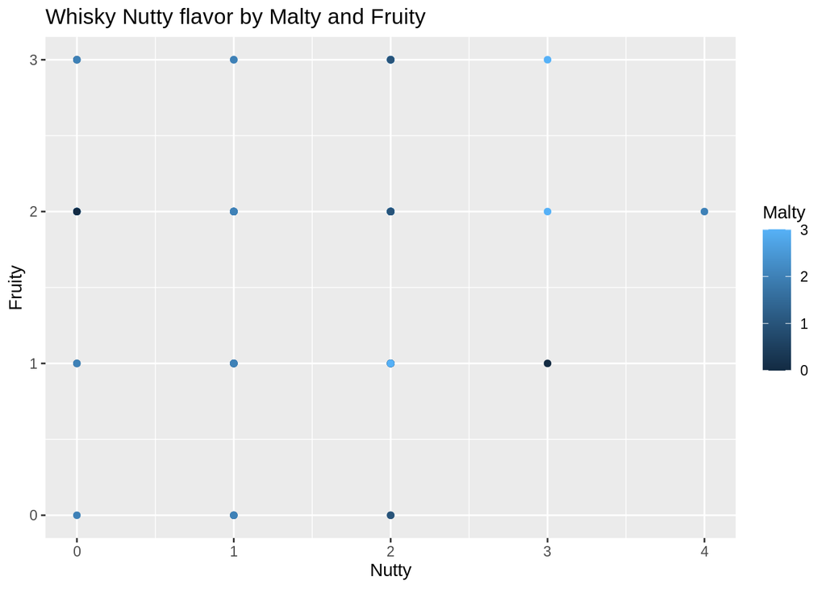

```r
ggplot(df, aes(x = Nutty,
                     y = Fruity,
                     color=Malty)) +
  geom_point() +
  labs(title = "Whisky Nutty flavor by Malty and Fruity ")
```